```python
%matplotlib inline

import matplotlib
import numpy as np
import matplotlib.pyplot as plt
```

# Working with text

This is a shortened version of the tutorial "Working with text" in the form of an interactive IPython notebook. This document is "live"; any code example can be edited and executed in the browser. To see this in action, change some part of the code in the *cell* below and then click on the play button above.

https://de.dariah.eu/tatom/working_with_text.html#creating-a-document-term-matrix

```python
list_of_strings = ['working', 'with', 'text']
for s in list_of_strings:
    print(s)
```

```
working
with
text
```

## Creating a document-term matrix

Word frequencies and document-term matrices are typical units of analysis when working with text collections. It may come as a surprise that reducing a book to a list of word frequencies retains useful information, but practice has shown this to be the case. Treating texts as a list of word frequencies (a vector) also makes available a range of mathematical tools developed for [studying and manipulating vectors](http://en.wikipedia.org/wiki/Euclidean_vector#History).

> **Note**: Turning texts into unordered lists (or "bags") of words is easy in Python. [Python Programming for the Humanities](http://fbkarsdorp.github.io/python-course/) includes a chapter entitled [Text Processing](http://nbviewer.ipython.org/urls/raw.github.com/fbkarsdorp/python-course/master/Chapter%203%20-%20Text%20Preprocessing.ipynb) that describes the steps in detail.

This document assumes some prior exposure to text analysis so we will gather word frequencies (or term frequencies) derived from the lists of words appearing in texts into a document-term matrix using the [CountVectorizer](http://scikit-learn.sourceforge.net/dev/modules/generated/sklearn.feature_extraction.text.CountVectorizer.html) class from the [scikit-learn](http://scikit-learn.sourceforge.net/) package. (For those familiar with R and the [tm](http://cran.r-project.org/web/packages/tm/) package, this function performs the same operation as `DocumentTermMatrix` and takes recognizably similar arguments.)

First we need to import the functions and classes we intend to use, along with our customary abbreviation for functions in the `numpy` package.

```python
import numpy as np  # a conventional alias
from sklearn.feature_extraction.text import CountVectorizer
```

Now we use the [CountVectorizer](http://scikit-learn.sourceforge.net/dev/modules/generated/sklearn.feature_extraction.text.CountVectorizer.html) class to create a document-term matrix. `CountVectorizer` is highly customizable. For example, a list of "stop words" can be specified with the `stop_words` parameter. Other important parameters include:

- `lowercase` (default `True`) convert all text to lowercase before tokenizing
- `min_df` (default `1`) remove from the vocabulary terms that occur in fewer than `min_df` documents–with a large corpus this may be set to `5` to eliminate rare words
- `vocabulary` ignore words that do not appear in the list (or iterable) assigned to parameter `vocabulary`
- `strip_accents` remove accents
- `token_pattern` (default `u'(?u)\b\w\w+\b'`) regular expression identifying tokens–by default words that consist of a single character (e.g., 'a', '2') are ignored, setting `token_pattern` to `'(?u)\b\w+\b'` will include these tokens
- `tokenizer` (default unused) use a custom function for tokenizing

For this example we will use texts by Jane Austen and Charlotte Brontë. These texts are available in the *Datasets* section of the collected tutorials.

```python
filenames = ['data/austen-brontë/Austen_Emma.txt',
             'data/austen-brontë/Austen_Pride.txt',
             'data/austen-brontë/Austen_Sense.txt',
             'data/austen-brontë/CBronte_Jane.txt',
             'data/austen-brontë/CBronte_Professor.txt',
             'data/austen-brontë/CBronte_Villette.txt']

vectorizer = CountVectorizer(input='filename')
#fit_transform is a method of the CountVectorizer object, you can learn about it
#at http://scikit-learn.org/stable/modules/generated/sklearn.feature_extraction.text.CountVectorizer.html
#Learn the vocabulary dictionary and return term-document matrix.
dtm = vectorizer.fit_transform(filenames)  # a sparse matrix
vocab_list = vectorizer.get_feature_names()
```

```python
print len(vocab_list)
dtm.get_shape()
#this is 6 by 22854, each row is a document, with its 22854 vocabs
```

```
22854
```

```
(6, 22854)
```

Now we have a document-term matrix and a vocabulary list. Before we can query the matrix and find out, for example, how many times the word 'house' occurs in *Emma* (the first text in `filenames`), we need to convert this matrix from its current format, a [sparse matrix](http://docs.scipy.org/doc/scipy/reference/sparse.html), into a normal NumPy array. We will also convert `vocab`, a list of vocabulary, to an array of strings, as an array supports a greater variety of operations.

```python
# for reference, note the current class of `dtm`
# dtm is basically a vector representation matrix of the documents
#convert both dtm and vocab to numpy array from the scipy sparse matrix
type(dtm)
dtm = dtm.toarray()  # convert to a regular array

#note that vocab_list is a python list, vocab is a numpy array
vocab = np.array(vocab_list)
```

```python
dtm.shape
```

```
(6, 22854)
```

```python
len(vocab)
```

```
22854
```

> **Note:** A sparse matrix is used to store matrices that contain a significant number of entries that are zero. Typically, a sparse matrix only records non-zero entries. To understand why this matters so much that `CountVectorizer` returns a sparse matrix by default, consider a 4000 by 50000 matrix that is 60% zeros. In Python an integer takes up 4 bytes, so using a sparse matrix saves almost 500M, which is a significant amount of computer memory. (Remember that arrays are usually stored in memory, not on disk).

Querying the document-term matrix and the vocabulary is straightforward. For example, here are two ways of finding how many times the word 'house' occurs in the first text, *Emma*:

```python
# the first file, indexed by 0 in Python, is *Emma*
filenames[0] == 'data/austen-brontë/Austen_Emma.txt'

# use the standard Python list method index(...)
house_idx = vocab_list.index('house')
print dtm[0, house_idx]

# verify that this is the result we anticipated
print vocab_list[house_idx]
print house_idx    #house index is 10164, and the value (of the number of occurrences) is 95

# alternatively, use NumPy indexing
#note that vocab_list is a python list, vocab is a numpy array, so the first usage above is particular to python
#list while the second usage below is particular to the numpy array
# in R this would be essentially the same, dtm[1, vocab == 'house']
dtm[0, vocab == 'house']


####some other words
and_idx = vocab_list.index('and')
print and_idx
print dtm[0, and_idx]
#and is 1143, and value is 4896, consistent with the value listed at the web version of this tutorial.
```

```
95
house
10164
1143
4896
```

## euclidean distance between doc vectors

```python
#look some cols of second row doc of dtm,
dtm[1][1140:1240]
```

```
array([   0,    0,    1, 3584,    0,    0,    2,    1,    0,    1,    0,
          3,    1,    0,    0,   13,    0,    0,    0,    0,    0,    0,
          0,    0,    0,    0,    0,    0,    1,   17,    2,    0,    0,
          1,    0,    0,    2,    0,    1,    4,    0,    1,    2,    0,
          0,    0,    0,    5,    0,    3,    1,    0,    0,    0,    0,
          0,    0,    4,    3,    0,    0,    0,    0,    0,    0,    1,
          0,    1,    0,    0,    0,    0,    2,    0,    0,    0,   58,
          0,   65,    2,   34,    3,    1,    0,    1,    0,    1,    0,
          1,    4,    2,    1,    0,    0,    0,    0,    0,    0,    0,
          0])
```

```python
dist = np.zeros((n, n))
print dist.shape
```

```
(6, 6)
```

```python
# "by hand", this is a dist matrix of
In [14]: n, _ = dtm.shape

In [15]: dist = np.zeros((n, n)) #this is a dist matrix n*n

In [16]: for i in range(n):
            for j in range(n):
                x, y = dtm[i, :], dtm[j, :]

                dist[i, j] = np.sqrt(np.sum((x - y)**2))
```

```python
print x,y
#notice the last line of dist[i,j] computation is a matrix operation, on these two rows basically.
#[0 1 0 ..., 0 0 1] [0 1 0 ..., 0 0 1]
print dist
print dist.shape #this is still a 6 by 6 matrix of dist matrix, each distance between two docs is computed by euclidean
#dist of its doc vector, by matrix operation.
```

```
[0 1 0 ..., 0 0 1] [0 1 0 ..., 0 0 1]
[[    0.          3856.28875993  4182.80109496  5119.70301873
   7113.27378919  5280.17244037]
 [ 3856.28875993     0.          1922.60500363  6313.08339878
   4126.23932898  6381.23875121]
 [ 4182.80109496  1922.60500363     0.          6657.36419313
   4045.34460831  6650.31202276]
 [ 5119.70301873  6313.08339878  6657.36419313     0.          8363.82765246
   2591.54664245]
 [ 7113.27378919  4126.23932898  4045.34460831  8363.82765246     0.
   8484.05557502]
 [ 5280.17244037  6381.23875121  6650.31202276  2591.54664245
   8484.05557502     0.        ]]
(6, 6)
```

```python
#with sklearn
In [17]: from sklearn.metrics.pairwise import euclidean_distances

In [18]: dist = euclidean_distances(dtm)
```

```python
dist
```

```
array([[    0.        ,  3856.28875993,  4182.80109496,  5119.70301873,
         7113.27378919,  5280.17244037],
       [ 3856.28875993,     0.        ,  1922.60500363,  6313.08339878,
         4126.23932898,  6381.23875121],
       [ 4182.80109496,  1922.60500363,     0.        ,  6657.36419313,
         4045.34460831,  6650.31202276],
       [ 5119.70301873,  6313.08339878,  6657.36419313,     0.        ,
         8363.82765246,  2591.54664245],
       [ 7113.27378919,  4126.23932898,  4045.34460831,  8363.82765246,
            0.        ,  8484.05557502],
       [ 5280.17244037,  6381.23875121,  6650.31202276,  2591.54664245,
         8484.05557502,     0.        ]])
```

```python
In [19]: np.round(dist, 1)
```

```
array([[    0. ,  3856.3,  4182.8,  5119.7,  7113.3,  5280.2],
       [ 3856.3,     0. ,  1922.6,  6313.1,  4126.2,  6381.2],
       [ 4182.8,  1922.6,     0. ,  6657.4,  4045.3,  6650.3],
       [ 5119.7,  6313.1,  6657.4,     0. ,  8363.8,  2591.5],
       [ 7113.3,  4126.2,  4045.3,  8363.8,     0. ,  8484.1],
       [ 5280.2,  6381.2,  6650.3,  2591.5,  8484.1,     0. ]])
```

```python
# *Pride and Prejudice* is index 1 and *Jane Eyre* is index 3
In [20]: filenames[1] == 'data/austen-brontë/Austen_Pride.txt'
In [21]: filenames[3] == 'data/austen-brontë/CBronte_Jane.txt'

# the distance between *Pride and Prejudice* and *Jane Eyre*
In [22]: dist[1, 3]

# which is greater than the distance between *Jane Eyre* and *Villette* (index 5)
In [23]: dist[1, 3] > dist[3, 5]
```

```
True
```

```python
#cosine similarity
In [24]: from sklearn.metrics.pairwise import cosine_similarity

In [25]: dist = 1 - cosine_similarity(dtm)

In [26]: np.round(dist, 2)


# the distance between *Pride and Prejudice* (index 1)
# and *Jane Eyre* (index 3) is
In [27]: dist[1, 3]

# which is greater than the distance between *Jane Eyre* and
# *Villette* (index 5)
In [28]: dist[1, 3] > dist[3, 5]
```

```
True
```

### Visualizing distances:

It is often desirable to visualize the pairwise distances between our texts. A general approach to visualizing distances is to assign a point in a plane to each text, making sure that the distance between points is proportional to the pairwise distances we calculated. This kind of visualization is common enough that it has a name, “multidimensional scaling” (MDS) and family of functions in scikit-learn (and R too, see mdscale).

### 2d MDS

```python
In [34]: import os  # for os.path.basename

In [35]: import matplotlib.pyplot as plt

In [36]: from sklearn.manifold import MDS

# two components as we're plotting points in a two-dimensional plane
# "precomputed" because we provide a distance matrix
# we will also specify `random_state` so the plot is reproducible.
In [37]: mds = MDS(n_components=2, dissimilarity="precomputed", random_state=1)

In [38]: pos = mds.fit_transform(dist)  # shape (n_components, n_samples)
```

```python
dist
```

```
array([[ -2.22044605e-16,   1.97991646e-02,   2.54477700e-02,
          5.33033683e-02,   5.85056420e-02,   5.47577694e-02],
       [  1.97991646e-02,   6.66133815e-16,   1.65970214e-02,
          4.70262343e-02,   4.31295508e-02,   4.32719403e-02],
       [  2.54477700e-02,   1.65970214e-02,   3.33066907e-16,
          5.60580626e-02,   4.68418996e-02,   4.90020814e-02],
       [  5.33033683e-02,   4.70262343e-02,   5.60580626e-02,
         -2.22044605e-16,   1.59794084e-02,   1.36726702e-02],
       [  5.85056420e-02,   4.31295508e-02,   4.68418996e-02,
          1.59794084e-02,   4.44089210e-16,   1.09404259e-02],
       [  5.47577694e-02,   4.32719403e-02,   4.90020814e-02,
          1.36726702e-02,   1.09404259e-02,   3.33066907e-16]])
```

```python
#from dist to pos, MDS has transformed a 6-d vector into 2-d
pos
```

```
array([[-0.02585817,  0.01864904],
       [-0.02056898,  0.00063341],
       [-0.0250226 , -0.01264309],
       [ 0.02537544,  0.00748636],
       [ 0.02226944, -0.01113521],
       [ 0.02380488, -0.00299051]])
```

```python
In [39]: xs, ys = pos[:, 0], pos[:, 1]
In [40]: names = [os.path.basename(fn).replace('.txt', '') for fn in filenames]
```

```python
xs
```

```
array([-0.02585817, -0.02056898, -0.0250226 ,  0.02537544,  0.02226944,
        0.02380488])
```

```python
ys
```

```
array([ 0.01864904,  0.00063341, -0.01264309,  0.00748636, -0.01113521,
       -0.00299051])
```

```python
names
```

```
['Austen_Emma',
 'Austen_Pride',
 'Austen_Sense',
 'CBronte_Jane',
 'CBronte_Professor',
 'CBronte_Villette']
```

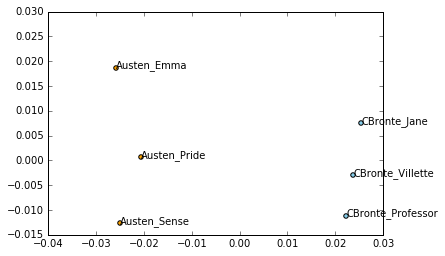

```python
# short versions of filenames:
# convert 'data/austen-brontë/Austen_Emma.txt' to 'Austen_Emma'
#use names for plotting

# color-blind-friendly palette
In [41]: for x, y, name in zip(xs, ys, names):
   ....:     color = 'orange' if "Austen" in name else 'skyblue'
   ....:     plt.scatter(x, y, c=color)
   ....:     plt.text(x, y, name)
   ....:

In [42]: plt.show()
```

### 3d MDS

```python
# après Jeremy M. Stober, Tim Vieira
# https://github.com/timvieira/viz/blob/master/mds.py
```

```python
In [43]: mds = MDS(n_components=3, dissimilarity="precomputed", random_state=1)
In [44]: pos = mds.fit_transform(dist)
In [45]: from mpl_toolkits.mplot3d import Axes3D
```

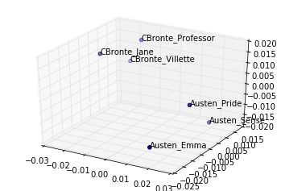

```python
In [46]: fig = plt.figure()

In [47]: ax = fig.add_subplot(111, projection='3d')

In [48]: ax.scatter(pos[:, 0], pos[:, 1], pos[:, 2])

In [49]: for x, y, z, s in zip(pos[:, 0], pos[:, 1], pos[:, 2], names):
   ....:     ax.text(x, y, z, s)


In [50]: plt.show()
```

## Doc clustering using hierarchical clustering

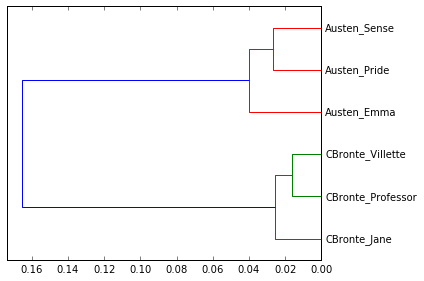

```python
In [51]: from scipy.cluster.hierarchy import ward, dendrogram

In [52]: linkage_matrix = ward(dist)

# match dendrogram to that returned by R's hclust()
In [53]: dendrogram(linkage_matrix, orientation="right", labels=names)

In [54]: plt.tight_layout()  # fixes margins

In [55]: plt.show()
```

# Sandbox

Feel free to experiment with the document-term matrix `dtm` in the code cells below.

```python
print(dtm.shape)
for fn in filenames:
    print(fn)
```

```
(6, 22854)
data/austen-brontë/Austen_Emma.txt
data/austen-brontë/Austen_Pride.txt
data/austen-brontë/Austen_Sense.txt
data/austen-brontë/CBronte_Jane.txt
data/austen-brontë/CBronte_Professor.txt
data/austen-brontë/CBronte_Villette.txt
```

```python
print(len(vocab))
vocab[500:550]  # look at some of the vocabulary
```

```
22854
```

```
array(['abuse', 'abused', 'abuses', 'abusing', 'abusive', 'abyss',
       'acacia', 'acacias', 'academician', 'academicians', 'accede',
       'acceded', 'acceding', 'accelerate', 'accelerated', 'accent',
       'accented', 'accents', 'accentuated', 'accept', 'acceptable',
       'acceptably', 'acceptance', 'accepted', 'accepting', 'accepts',
       'access', 'accessible', 'accession', 'accessory', 'accident',
       'accidental', 'accidentally', 'accidently', 'accidents',
       'accommodate', 'accommodated', 'accommodating', 'accommodation',
       'accommodations', 'accompanied', 'accompanies', 'accompaniment',
       'accompaniments', 'accompany', 'accompanying', 'accompli',
       'accomplices', 'accomplish', 'accomplished'],
      dtype='<U20')
```

# Preprocessing

```python
import os, glob
import numpy as np
```

```python
corpus_path = os.path.join('data', 'french-tragedy')
```

```python
corpus_path
```

```
'data/french-tragedy'
```

```python
tragedy_filenames = glob.glob(corpus_path + os.sep + '*.txt')
```

```python
tragedy_filenames
```

```
['data/french-tragedy/Crebillon_TR-V-1703-Idomenee.txt',
 'data/french-tragedy/Crebillon_TR-V-1707-Atree.txt',
 'data/french-tragedy/Crebillon_TR-V-1708-Electre.txt',
 'data/french-tragedy/Crebillon_TR-V-1711-Rhadamisthe.txt',
 'data/french-tragedy/Crebillon_TR-V-1717-Semiramis.txt',
 'data/french-tragedy/Crebillon_TR-V-1726-Pyrrhus.txt',
 'data/french-tragedy/Crebillon_TR-V-1749-Catilina.txt',
 'data/french-tragedy/Crebillon_TR-V-1749-Xerces.txt',
 'data/french-tragedy/Crebillon_TR-V-1754-Triumvirat.txt',
 'data/french-tragedy/PCorneille_TR-V-1639-Medee.txt',
 'data/french-tragedy/PCorneille_TR-V-1639-Nicomede.txt',
 'data/french-tragedy/PCorneille_TR-V-1641-Horace.txt',
 'data/french-tragedy/PCorneille_TR-V-1643-Cinna.txt',
 'data/french-tragedy/PCorneille_TR-V-1643-Polyeucte.txt',
 'data/french-tragedy/PCorneille_TR-V-1644-Pompee.txt',
 'data/french-tragedy/PCorneille_TR-V-1644-Rodogune.txt',
 'data/french-tragedy/PCorneille_TR-V-1645-Theodore.txt',
 'data/french-tragedy/PCorneille_TR-V-1647-Heraclius.txt',
 'data/french-tragedy/PCorneille_TR-V-1651-Andromede.txt',
 'data/french-tragedy/PCorneille_TR-V-1653-Pertharite.txt',
 'data/french-tragedy/PCorneille_TR-V-1659-Oedipe.txt',
 'data/french-tragedy/PCorneille_TR-V-1661-Toisondor.txt',
 'data/french-tragedy/PCorneille_TR-V-1662-Sertorius.txt',
 'data/french-tragedy/PCorneille_TR-V-1663-Sophonisbe.txt',
 'data/french-tragedy/PCorneille_TR-V-1665-Othon.txt',
 'data/french-tragedy/PCorneille_TR-V-1666-Agesilas.txt',
 'data/french-tragedy/PCorneille_TR-V-1668-Attila.txt',
 'data/french-tragedy/PCorneille_TR-V-1672-Pulcherie.txt',
 'data/french-tragedy/PCorneille_TR-V-1674-Surena.txt',
 'data/french-tragedy/Racine_TR-V-1664-Thebaide.txt',
 'data/french-tragedy/Racine_TR-V-1666-Alexandre.txt',
 'data/french-tragedy/Racine_TR-V-1668-Andromaque.txt',
 'data/french-tragedy/Racine_TR-V-1670-Britannicus.txt',
 'data/french-tragedy/Racine_TR-V-1671-Berenice.txt',
 'data/french-tragedy/Racine_TR-V-1672-Bajazet.txt',
 'data/french-tragedy/Racine_TR-V-1673-Mithridate.txt',
 'data/french-tragedy/Racine_TR-V-1674-Iphigenie.txt',
 'data/french-tragedy/Racine_TR-V-1677-Phedre.txt',
 'data/french-tragedy/Racine_TR-V-1689-Esther.txt',
 'data/french-tragedy/Racine_TR-V-1691-Athalie.txt',
 'data/french-tragedy/Voltaire_TR-V-1718-Oedipe.txt',
 'data/french-tragedy/Voltaire_TR-V-1724-Mariamne.txt',
 'data/french-tragedy/Voltaire_TR-V-1730-Brutus.txt',
 'data/french-tragedy/Voltaire_TR-V-1732-Alzire.txt',
 'data/french-tragedy/Voltaire_TR-V-1732-Zaire.txt',
 'data/french-tragedy/Voltaire_TR-V-1734-Agathocle.txt',
 'data/french-tragedy/Voltaire_TR-V-1741-Fanatisme.txt',
 'data/french-tragedy/Voltaire_TR-V-1743-Merope.txt',
 'data/french-tragedy/Voltaire_TR-V-1743-MortCesar.txt',
 'data/french-tragedy/Voltaire_TR-V-1749-LoisMinos.txt',
 'data/french-tragedy/Voltaire_TR-V-1750-RomeSauvee.txt',
 'data/french-tragedy/Voltaire_TR-V-1751-DucDAlencon.txt',
 'data/french-tragedy/Voltaire_TR-V-1755-OrphelinChine.txt',
 'data/french-tragedy/Voltaire_TR-V-1764-Olympie.txt',
 'data/french-tragedy/Voltaire_TR-V-1766-AdelaideDuGuesclin.txt',
 'data/french-tragedy/Voltaire_TR-V-1769-Guebres.txt',
 'data/french-tragedy/Voltaire_TR-V-1771-Tancrede.txt',
 'data/french-tragedy/Voltaire_TR-V-1774-Sophonisbee.txt',
 'data/french-tragedy/Voltaire_TR-V-1778-Irene.txt']
```

```python
(7.6+4.7)/(7.6+4.7+1.7+25.4)
```

```
0.3121827411167513
```

### split into chunks

```python
In [31]: def split_text(filename, n_words):
   ....:     """Split a text into chunks approximately `n_words` words in length."""
   ....:     input = open(filename, 'r')
   ....:     words = input.read().split(' ')
   ....:     input.close()
   ....:     chunks = []
   ....:     current_chunk_words = []
   ....:     current_chunk_word_count = 0
   ....:     for word in words:
   ....:         current_chunk_words.append(word)
   ....:         current_chunk_word_count += 1
   ....:         if current_chunk_word_count == n_words:
   ....:             chunks.append(' '.join(current_chunk_words))
   ....:             current_chunk_words = []
   ....:             current_chunk_word_count = 0
   ....:     chunks.append(' '.join(current_chunk_words) )
   ....:     return chunks
   ....:
```

```python
In [32]: tragedy_filenames = [os.path.join(corpus_path, fn) for fn in sorted(os.listdir(corpus_path))]

# alternatively, using glob
In [33]: tragedy_filenames = glob.glob(corpus_path + os.sep + '*.txt')

# for consistency across platforms (Linux, OS X, Windows) we must sort the filenames
In [34]: tragedy_filenames.sort()

In [35]: chunk_length = 1000

In [36]: chunks = []

In [37]: for filename in tragedy_filenames:
   ....:     chunk_counter = 0
   ....:     texts = split_text(filename, chunk_length)
   ....:     for text in texts:
   ....:         chunk = {'text': text, 'number': chunk_counter, 'filename': filename}
   ....:         chunks.append(chunk)
   ....:         chunk_counter += 1
   ....:
```

```python
# from the triples we can create a document-term matrix
In [40]: from sklearn.feature_extraction.text import CountVectorizer

In [41]: vectorizer = CountVectorizer(min_df=5, max_df=.95)

In [42]: dtm = vectorizer.fit_transform([c['text'] for c in chunks])

In [43]: vocab = np.array(vectorizer.get_feature_names())
```

```python
dtm
```

```
<2740x6883 sparse matrix of type '<type 'numpy.int64'>'
	with 436619 stored elements in Compressed Sparse Row format>
```

```python
len(chunks)
```

```
2740
```

```python
vocab.size
```

```
6883
```

```python
# make sure the directory exists
In [44]: output_dir = '/tmp/'

In [45]: for chunk in chunks:
   ....:     basename = os.path.basename(chunk['filename'])
   ....:     fn = os.path.join(output_dir,
   ....:                       "{}{:04d}".format(basename, chunk['number']))
   ....:     with open(fn, 'w') as f:
   ....:         f.write(chunk['text'])
   ....:
```

### analysis by author

```python
tragedy_filenames
```

```
['data/french-tragedy/Crebillon_TR-V-1703-Idomenee.txt',
 'data/french-tragedy/Crebillon_TR-V-1707-Atree.txt',
 'data/french-tragedy/Crebillon_TR-V-1708-Electre.txt',
 'data/french-tragedy/Crebillon_TR-V-1711-Rhadamisthe.txt',
 'data/french-tragedy/Crebillon_TR-V-1717-Semiramis.txt',
 'data/french-tragedy/Crebillon_TR-V-1726-Pyrrhus.txt',
 'data/french-tragedy/Crebillon_TR-V-1749-Catilina.txt',
 'data/french-tragedy/Crebillon_TR-V-1749-Xerces.txt',
 'data/french-tragedy/Crebillon_TR-V-1754-Triumvirat.txt',
 'data/french-tragedy/PCorneille_TR-V-1639-Medee.txt',
 'data/french-tragedy/PCorneille_TR-V-1639-Nicomede.txt',
 'data/french-tragedy/PCorneille_TR-V-1641-Horace.txt',
 'data/french-tragedy/PCorneille_TR-V-1643-Cinna.txt',
 'data/french-tragedy/PCorneille_TR-V-1643-Polyeucte.txt',
 'data/french-tragedy/PCorneille_TR-V-1644-Pompee.txt',
 'data/french-tragedy/PCorneille_TR-V-1644-Rodogune.txt',
 'data/french-tragedy/PCorneille_TR-V-1645-Theodore.txt',
 'data/french-tragedy/PCorneille_TR-V-1647-Heraclius.txt',
 'data/french-tragedy/PCorneille_TR-V-1651-Andromede.txt',
 'data/french-tragedy/PCorneille_TR-V-1653-Pertharite.txt',
 'data/french-tragedy/PCorneille_TR-V-1659-Oedipe.txt',
 'data/french-tragedy/PCorneille_TR-V-1661-Toisondor.txt',
 'data/french-tragedy/PCorneille_TR-V-1662-Sertorius.txt',
 'data/french-tragedy/PCorneille_TR-V-1663-Sophonisbe.txt',
 'data/french-tragedy/PCorneille_TR-V-1665-Othon.txt',
 'data/french-tragedy/PCorneille_TR-V-1666-Agesilas.txt',
 'data/french-tragedy/PCorneille_TR-V-1668-Attila.txt',
 'data/french-tragedy/PCorneille_TR-V-1672-Pulcherie.txt',
 'data/french-tragedy/PCorneille_TR-V-1674-Surena.txt',
 'data/french-tragedy/Racine_TR-V-1664-Thebaide.txt',
 'data/french-tragedy/Racine_TR-V-1666-Alexandre.txt',
 'data/french-tragedy/Racine_TR-V-1668-Andromaque.txt',
 'data/french-tragedy/Racine_TR-V-1670-Britannicus.txt',
 'data/french-tragedy/Racine_TR-V-1671-Berenice.txt',
 'data/french-tragedy/Racine_TR-V-1672-Bajazet.txt',
 'data/french-tragedy/Racine_TR-V-1673-Mithridate.txt',
 'data/french-tragedy/Racine_TR-V-1674-Iphigenie.txt',
 'data/french-tragedy/Racine_TR-V-1677-Phedre.txt',
 'data/french-tragedy/Racine_TR-V-1689-Esther.txt',
 'data/french-tragedy/Racine_TR-V-1691-Athalie.txt',
 'data/french-tragedy/Voltaire_TR-V-1718-Oedipe.txt',
 'data/french-tragedy/Voltaire_TR-V-1724-Mariamne.txt',
 'data/french-tragedy/Voltaire_TR-V-1730-Brutus.txt',
 'data/french-tragedy/Voltaire_TR-V-1732-Alzire.txt',
 'data/french-tragedy/Voltaire_TR-V-1732-Zaire.txt',
 'data/french-tragedy/Voltaire_TR-V-1734-Agathocle.txt',
 'data/french-tragedy/Voltaire_TR-V-1741-Fanatisme.txt',
 'data/french-tragedy/Voltaire_TR-V-1743-Merope.txt',
 'data/french-tragedy/Voltaire_TR-V-1743-MortCesar.txt',
 'data/french-tragedy/Voltaire_TR-V-1749-LoisMinos.txt',
 'data/french-tragedy/Voltaire_TR-V-1750-RomeSauvee.txt',
 'data/french-tragedy/Voltaire_TR-V-1751-DucDAlencon.txt',
 'data/french-tragedy/Voltaire_TR-V-1755-OrphelinChine.txt',
 'data/french-tragedy/Voltaire_TR-V-1764-Olympie.txt',
 'data/french-tragedy/Voltaire_TR-V-1766-AdelaideDuGuesclin.txt',
 'data/french-tragedy/Voltaire_TR-V-1769-Guebres.txt',
 'data/french-tragedy/Voltaire_TR-V-1771-Tancrede.txt',
 'data/french-tragedy/Voltaire_TR-V-1774-Sophonisbee.txt',
 'data/french-tragedy/Voltaire_TR-V-1778-Irene.txt']
```

```python
len(tragedy_filenames)
```

```
59
```

```python
# first get a document-term-matrix of word frequencies for our corpus
In [69]: vectorizer = CountVectorizer(input='filename')

In [70]: dtm = vectorizer.fit_transform(tragedy_filenames).toarray()

In [71]: vocab = np.array(vectorizer.get_feature_names())
```

```python
dtm.shape
```

```
(59, 16607)
```

```python
In [72]: authors = np.array([os.path.basename(filename).split('_')[0] for filename in tragedy_filenames])

authors
```

```
array(['Crebillon', 'Crebillon', 'Crebillon', 'Crebillon', 'Crebillon',
       'Crebillon', 'Crebillon', 'Crebillon', 'Crebillon', 'PCorneille',
       'PCorneille', 'PCorneille', 'PCorneille', 'PCorneille',
       'PCorneille', 'PCorneille', 'PCorneille', 'PCorneille',
       'PCorneille', 'PCorneille', 'PCorneille', 'PCorneille',
       'PCorneille', 'PCorneille', 'PCorneille', 'PCorneille',
       'PCorneille', 'PCorneille', 'PCorneille', 'Racine', 'Racine',
       'Racine', 'Racine', 'Racine', 'Racine', 'Racine', 'Racine',
       'Racine', 'Racine', 'Racine', 'Voltaire', 'Voltaire', 'Voltaire',
       'Voltaire', 'Voltaire', 'Voltaire', 'Voltaire', 'Voltaire',
       'Voltaire', 'Voltaire', 'Voltaire', 'Voltaire', 'Voltaire',
       'Voltaire', 'Voltaire', 'Voltaire', 'Voltaire', 'Voltaire',
       'Voltaire'],
      dtype='|S10')
```

```python
len(authors)
```

```
59
```

```python
# allocate an empty array to store our aggregated word frequencies
In [73]: authors_unique = sorted(set(authors))

In [74]: dtm_authors = np.zeros((len(authors_unique), len(vocab)))

#this is basically array summation, just sum up all the positions, using np.sum
In [75]: for i, author in enumerate(authors_unique):
   ....:     dtm_authors[i, :] = np.sum(dtm[authors==author, :], axis=0)
   ....:
```

```python
#organize by four authors, each author's vector
dtm_authors.shape
```

```
(4, 16607)
```

```python
vocab.size
```

```
16607
```

```python
#try to understand what happned above
for author in authors_unique:
    a=dtm[authors==author,:]
    print a.shape
```

```
(9, 16607)
(20, 16607)
(11, 16607)
(19, 16607)
```

```python
a.shape
```

[output not shown]

### doing the same thing using pandas

```python
In [76]: import pandas

In [77]: authors = [os.path.basename(filename).split('_')[0] for filename in tragedy_filenames]

In [78]: dtm_authors = pandas.DataFrame(dtm).groupby(authors).sum().values
```

```python
dtm_authors.shape
```

```
(4, 16607)
```

### authors relationships

```python
In [98]: import matplotlib

In [99]: import matplotlib.pyplot as plt

In [100]: from sklearn.manifold import MDS

In [101]: from sklearn.metrics.pairwise import cosine_similarity

In [102]: dist = 1 - cosine_similarity(dtm_authors)

In [103]: mds = MDS(n_components=2, dissimilarity="precomputed")

In [104]: pos = mds.fit_transform(dist)  # shape (n_components, n_samples)
```

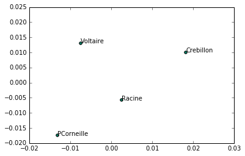

```python
In [98]: import matplotlib

In [99]: import matplotlib.pyplot as plt

In [100]: from sklearn.manifold import MDS

In [101]: from sklearn.metrics.pairwise import cosine_similarity

In [102]: dist = 1 - cosine_similarity(dtm_authors)

In [103]: mds = MDS(n_components=2, dissimilarity="precomputed")

In [104]: pos = mds.fit_transform(dist)  # shape (n_components, n_samples)
In [105]: xs, ys = pos[:, 0], pos[:, 1]

In [106]: names = sorted(set(authors))

In [107]: for x, y, name in zip(xs, ys, names):
   .....:     color = matplotlib.cm.summer(names.index(name))
   .....:     plt.scatter(x, y, c=color)
   .....:     plt.text(x, y, name)
   .....:

In [108]: plt.show()
```

```python
authors_unique
```

```
['Crebillon', 'PCorneille', 'Racine', 'Voltaire']
```

# Feature selection: finding distinctive words

```python
filenames
```

```
['data/austen-bront\xc3\xab/Austen_Emma.txt',
 'data/austen-bront\xc3\xab/Austen_Pride.txt',
 'data/austen-bront\xc3\xab/Austen_Sense.txt',
 'data/austen-bront\xc3\xab/CBronte_Jane.txt',
 'data/austen-bront\xc3\xab/CBronte_Professor.txt',
 'data/austen-bront\xc3\xab/CBronte_Villette.txt']
```

```python
In [2]: import os

In [3]: import nltk

In [4]: import numpy as np

In [5]: from sklearn.feature_extraction.text import CountVectorizer

In [6]: filenames_with_path = [fn for fn in filenames]

# these texts have underscores ('_') that indicate italics; remove them.
In [7]: raw_texts = []

In [8]: for fn in filenames_with_path:
   ...:     with open(fn) as f:
   ...:         text = f.read()
   ...:         text = text.replace('_', '')  # remove underscores (italics)
   ...:         raw_texts.append(text)
   ...:

In [9]: vectorizer = CountVectorizer(input='content')

In [10]: dtm = vectorizer.fit_transform(raw_texts)

In [11]: vocab = np.array(vectorizer.get_feature_names())

# fit_transform returns a sparse matrix (which uses less memory)
# but we want to work with a normal numpy array.
In [12]: dtm = dtm.toarray()

# normalize counts to rates per 1000 words
In [13]: rates = 1000 * dtm / np.sum(dtm, axis=1, keepdims=True)
```

```python
dtm
```

```
array([[2, 2, 0, ..., 0, 0, 0],
       [0, 1, 0, ..., 0, 0, 0],
       [0, 1, 0, ..., 0, 0, 0],
       [0, 0, 0, ..., 1, 0, 0],
       [0, 0, 1, ..., 0, 1, 0],
       [0, 1, 0, ..., 0, 0, 1]])
```

```python
dtm.shape
```

```
(6, 22524)
```

```python
rates.shape
```

```
(6, 22524)
```

```python
rates>4
```

```
array([[False, False, False, ..., False, False, False],
       [False, False, False, ..., False, False, False],
       [False, False, False, ..., False, False, False],
       [False, False, False, ..., False, False, False],
       [False, False, False, ..., False, False, False],
       [False, False, False, ..., False, False, False]], dtype=bool)
```

```python
a = np.array([[1, 2], [3, 4]])
```

```python
a<2
```

```
array([[ True, False],
       [False, False]], dtype=bool)
```

```python
np.mean(a<2)
```

```
0.25
```